# Analyses of GSE242766

M(6)A reduction relieves FUS-associated ALS granules.

Alexandre Kaizeler[^1] - alexandreafonso@gimm.pt<

24 July 2026

# Introduction

In this document, I present all analyses pertaining to the dataset **GSE242766**  
([NCBI GEO Link](https://www.ncbi.nlm.nih.gov/geo/query/acc.cgi?acc=GSE242766)),  
originally published by **G. Di Timoteo, 2024**.

```r
# These are all the libraries I used throughout the analysis. Not all of them will be required on this guidebook
library(Rsubread)
library(limma)
library(edgeR)
library(DESeq2)
library(magrittr)
library(ggrepel)
library(tidyverse)
library(vsn)
library(ggplot2)
library(NMF)
library(biomaRt)
library(ggpubr)
library(factoextra)
library(ggfortify)
library(plotly)
library(reshape2)
library(fgsea)
library(msigdbr)
library(data.table)
library(colorspace)

set.seed(1906)
```

## First Steps

```r
#This section here is to load up the genelenght file I will be using throughout the analyses.
genelength <- read.csv("~/Projects/StressGranules/SG_Transcriptome/RP_Data_2021/TrimmedSamples/alignment_STAR/TranscriptLenght.txt", header=T)

genelength <- subset(genelength, Ensembl.Canonical==1)
genelength <- subset(genelength, Gene.name!="")

genelength <- genelength %>%
  group_by(Gene.name) %>%
  slice(which.max(Transcript.length..including.UTRs.and.CDS.)) %>%
  ungroup()

genelength <- genelength[,-c(2,3)]
colnames(genelength) <- c("Length", "Gene")

#Get the table of read counts by indicating the path to the file. This file is obtained from the GEO dataset site.
raw.read.counts <- fread("~/Projects/StressGranules/SG_Transcriptome/m6A/GSE242766_counts_table.tsv")

biomart <- fread("~/biomart.txt")[,-2]


colnames(raw.read.counts)[1] <- "ensembl_gene_id"
colnames(biomart) <- c("ensembl_gene_id", "hgnc_symbol")

eltable <- merge(raw.read.counts,biomart,by = "ensembl_gene_id", all= TRUE) #this creates a table with both ensemble ids and HGNC codes.

eltable <- subset(eltable, hgnc_symbol!="") #this removes reads that dont have a corresponding hgnc symbol.

eltable$ensembl_gene_id <- NULL

read.counts <- eltable %>% # If two gene ids resulted in the same gene name, this will sum up their counts
  group_by(hgnc_symbol) %>%
  summarise(across(everything(), sum, na.rm = TRUE))
read.counts <- as.data.frame(read.counts)

row.names(read.counts) <- read.counts$hgnc_symbol #changes rownames into hgnc symbols
read.counts$hgnc_symbol <- NULL #We no longer need this column, as we have the rownames.
```

## Section for SPINSIM Preparation

This serves as an example.

```r
mof <- fread("~/Projects/StressGranules/Simulator/MolecularWeights.csv")
colnames(mof)[2] <- "GeneID"
mof <- mof[!duplicated(mof$GeneID), ]


stress.tpm <- read.counts[,16]
stress.tpm <- as.data.frame(stress.tpm)
stress.tpm$GeneID <- row.names(read.counts)
colnames(genelength) <- c("Length", "GeneID")
stress.tpm <- merge(stress.tpm, genelength, by="GeneID")
stress.tpm$TPM <- (stress.tpm$stress.tpm)/stress.tpm$Length
stress.tpm$TPM <- (stress.tpm$TPM * 1e6)
stress.tpm$TPM <- stress.tpm$TPM / sum(stress.tpm$TPM)
stress.tpm <- stress.tpm[,-2]
stress.tpm <- merge(stress.tpm, mof, by="GeneID")
write.table(x = stress.tpm,
            file = "~/Projects/StressGranules/Simulator/OriginalSamples/m6A/WTEX2.txt",
            sep="\t", col.names = TRUE, row.names = FALSE, quote=FALSE)
```

## Extra Quality Control

Let’s check for sample complexity. It is possible that one or more samples have different complexity. In specific, I am going to check if enough reads have been obtained from every sample. If not, we should have a great bias to housekeeping genes. Another way to put it, is to say that even with all reads, we won’t obtain a great deal of different genes.

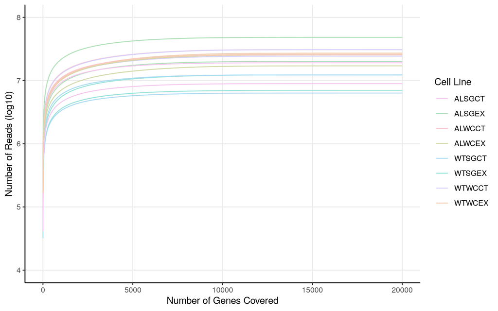

```r
# Define color palette
custom_palette <- qualitative_hcl(8, palette = "Pastel")
custom_palette <- sample(custom_palette, 8)

# Use SampleColouring from metadata
SampleColouring  <- c("ALWCCT","WTWCCT","ALWCEX","WTSGEX","WTSGCT","ALSGEX","ALSGCT","WTWCEX","WTWCCT","ALWCEX","ALWCCT","WTSGEX","WTSGCT","ALSGEX","ALSGCT","WTWCEX")

# Build cumulative counts
final <- sapply(1:ncol(read.counts), function(i) {
  sort_vals <- read.counts[order(read.counts[, i], decreasing = TRUE), i]
  cumsum(sort_vals)
})
final <- as.data.frame(final)
colnames(final) <- colnames(read.counts)

# Melt and add gene position + sample info
finalmelt <- reshape2::melt(final, variable.name = "Sample")
finalmelt$genes <- rep(1:nrow(final), times = ncol(final))
finalmelt$SampleColouring <- rep(SampleColouring, each = nrow(final))

# Plot cumulative read coverage
ggplot(data = finalmelt, aes(x = genes, y = log10(value), group = Sample, color = SampleColouring)) +
  geom_line() +
  scale_color_manual(values = custom_palette, name = "Cell Line") +
  theme_bw() +
  xlab("Number of Genes Covered") +
  ylab("Number of Reads (log10)") +
  xlim(0, 20000) +
  ylim(4, 8) +
  theme(
    axis.line = element_line(colour = "black"),
    panel.grid.minor = element_blank(),
    panel.border = element_blank(),
    panel.background = element_blank()
  )
```

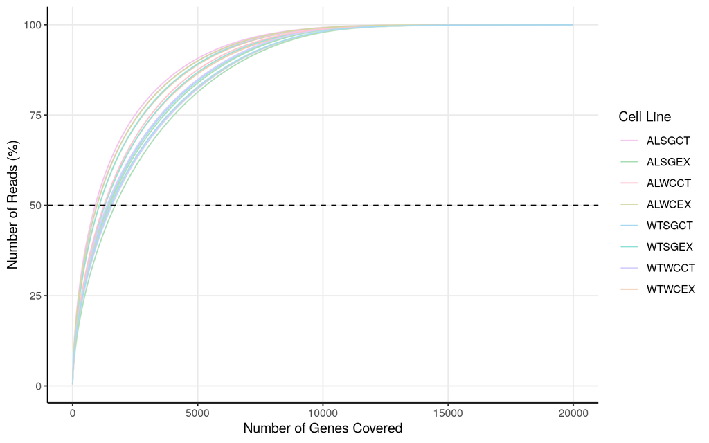

```r
# Create percentage-based plot
orderfinal <- subset(finalmelt, genes == max(finalmelt$genes))
trial <- merge(orderfinal[, c("Sample", "value")], finalmelt, by = "Sample", suffixes = c(".total", ".current"))
trial$percent <- (trial$value.current / trial$value.total) * 100
trial$SampleColouring <- rep(SampleColouring, each = nrow(final))

ggplot(data = trial, aes(x = genes, y = percent, group = Sample, color = SampleColouring)) +
  geom_line() +
  geom_hline(yintercept = 50, linetype = "dashed") +
  scale_color_manual(values = custom_palette, name = "Cell Line") +
  xlab("Number of Genes Covered") +
  ylab("Number of Reads (%)") +
  xlim(0, 20000) +
  theme_bw() +
  theme(
    axis.line = element_line(colour = "black"),
    panel.grid.minor = element_blank(),
    panel.border = element_blank(),
    panel.background = element_blank()
  )
```

As we can see in these plots, in this case there are no individual sample outliers in terms of complexity or read depth. Excellent!

# Differential Expression Analysis

## Filtration

### *Before Filtration*

Let us begin with the filtration. Personally, I find that its easier to do visually. I am aware that my filtration is more violent than most. Usually, from RNA-Seq experiments, we commonly obtain bi-modal distributions, with the first mode corresponding to lowly expressed genes. I remove these by cutting just before the second mode.

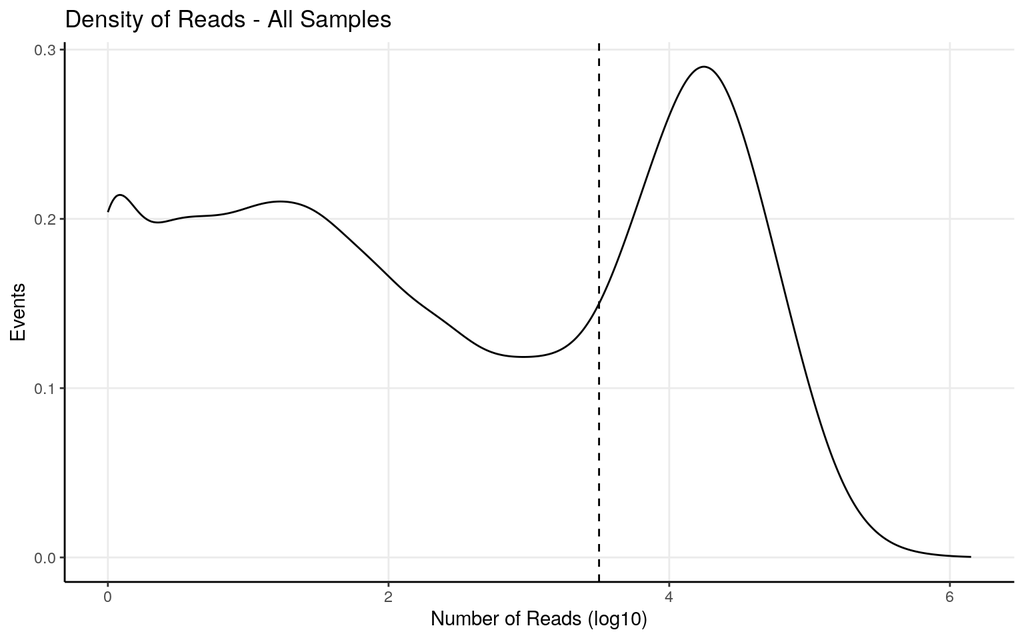

```r
alternew.ALSWC_ND <- log10(rowSums(read.counts[,c(1,11)]))
alternew.ALSWC_ND <- as.data.frame(alternew.ALSWC_ND)

alternew.ALSSG_ND <- log10(rowSums(read.counts[,c(2,9)]))
alternew.ALSSG_ND <- as.data.frame(alternew.ALSSG_ND)

alternew.WTWC_ND <- log10(rowSums(read.counts[,c(3,10)]))
alternew.WTWC_ND <- as.data.frame(alternew.WTWC_ND)

alternew.WTSG_ND <- log10(rowSums(read.counts[,c(4,12)]))
alternew.WTSG_ND <- as.data.frame(alternew.WTSG_ND)

alternew.ALSWC_D <- log10(rowSums(read.counts[,c(5,13)]))
alternew.ALSWC_D <- as.data.frame(alternew.ALSWC_D)

alternew.ALSSG_D <- log10(rowSums(read.counts[,c(6,14)]))
alternew.ALSSG_D <- as.data.frame(alternew.ALSSG_D)

alternew.WTWC_D <- log10(rowSums(read.counts[,c(7,15)]))
alternew.WTWC_D <- as.data.frame(alternew.WTWC_D)

alternew.WTSG_D <- log10(rowSums(read.counts[,c(8,16)]))
alternew.WTSG_D <- as.data.frame(alternew.WTSG_D)

alternew <- log10(rowSums(read.counts))
alternew <- as.data.frame(alternew)

ggplot(alternew, aes(x=alternew)) + geom_density() + theme_bw() + geom_vline(xintercept = 3.5, linetype = "dashed") + ylab("Events") + xlab("Number of Reads (log10)") +
  theme(axis.line = element_line(colour = "black"),
        panel.grid.minor = element_blank(),
        panel.border = element_blank(),
        panel.background = element_blank()) + ggtitle("Density of Reads - All Samples")
```

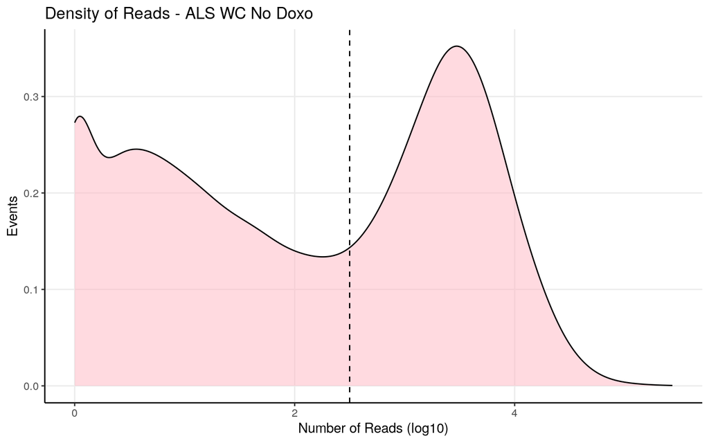

```r
ggplot(alternew.ALSWC_ND, aes(x=alternew.ALSWC_ND)) + geom_density(fill="#FFB6C1", alpha=0.5) + theme_bw() + geom_vline(xintercept = 2.5, linetype = "dashed") + ylab("Events") + xlab("Number of Reads (log10)") +
  theme(axis.line = element_line(colour = "black"),
        panel.grid.minor = element_blank(),
        panel.border = element_blank(),
        panel.background = element_blank()) + ggtitle("Density of Reads - ALS WC No Doxo")
```

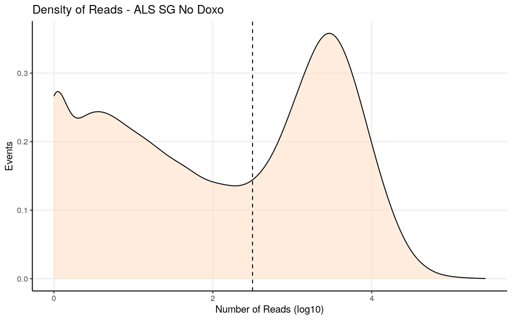

```r
ggplot(alternew.ALSSG_ND, aes(x=alternew.ALSSG_ND)) + geom_density(fill="#FFDAB9", alpha=0.5) + theme_bw() + geom_vline(xintercept = 2.5, linetype = "dashed") + ylab("Events") + xlab("Number of Reads (log10)") +
  theme(axis.line = element_line(colour = "black"),
        panel.grid.minor = element_blank(),
        panel.border = element_blank(),
        panel.background = element_blank()) + ggtitle("Density of Reads - ALS SG No Doxo")
```

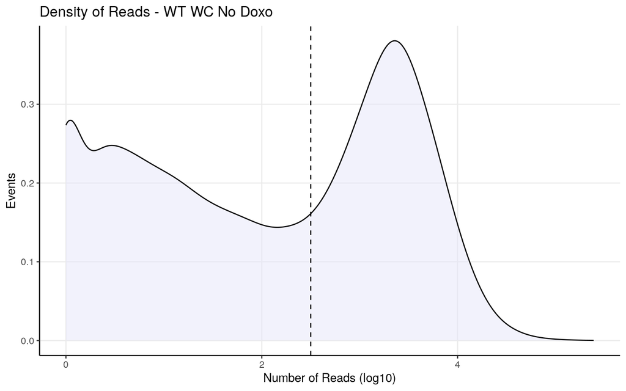

```r
ggplot(alternew.WTWC_ND, aes(x=alternew.WTWC_ND)) + geom_density(fill="#E6E6FA", alpha=0.5) + theme_bw() + geom_vline(xintercept = 2.5, linetype = "dashed") + ylab("Events") + xlab("Number of Reads (log10)") +
  theme(axis.line = element_line(colour = "black"),
        panel.grid.minor = element_blank(),
        panel.border = element_blank(),
        panel.background = element_blank()) + ggtitle("Density of Reads - WT WC No Doxo")
```

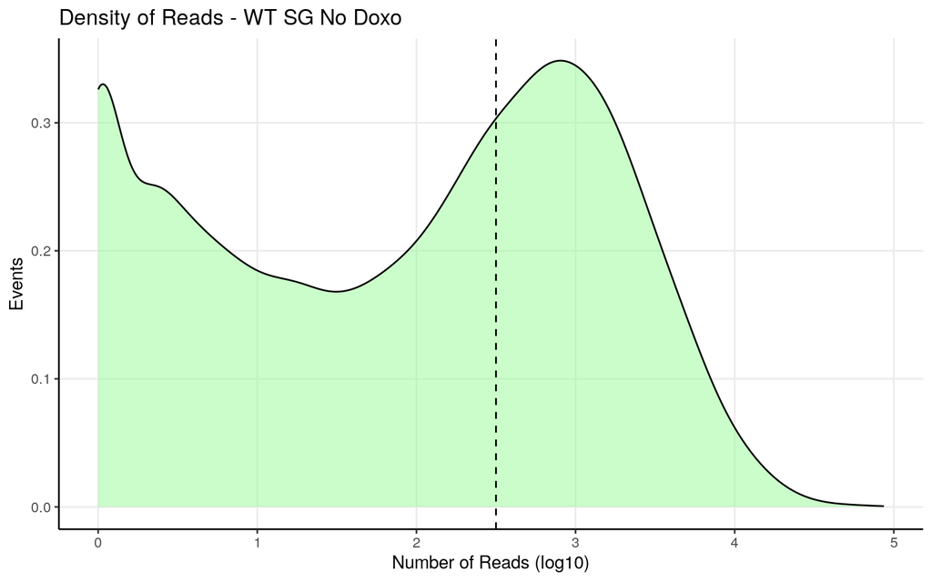

```r
ggplot(alternew.WTSG_ND, aes(x=alternew.WTSG_ND)) + geom_density(fill="#98FB98", alpha=0.5) + theme_bw() + geom_vline(xintercept = 2.5, linetype = "dashed") + ylab("Events") + xlab("Number of Reads (log10)") +
  theme(axis.line = element_line(colour = "black"),
        panel.grid.minor = element_blank(),
        panel.border = element_blank(),
        panel.background = element_blank()) + ggtitle("Density of Reads - WT SG No Doxo")
```

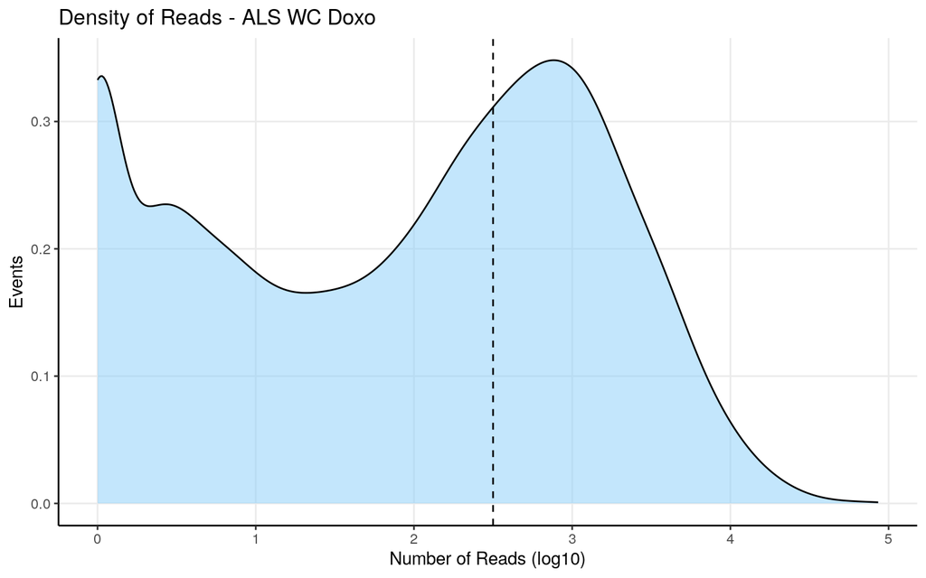

```r
ggplot(alternew.ALSWC_D, aes(x=alternew.ALSWC_D)) + geom_density(fill="#87CEFA", alpha=0.5) + theme_bw() + geom_vline(xintercept = 2.5, linetype = "dashed") + ylab("Events") + xlab("Number of Reads (log10)") +
  theme(axis.line = element_line(colour = "black"),
        panel.grid.minor = element_blank(),
        panel.border = element_blank(),
        panel.background = element_blank()) + ggtitle("Density of Reads - ALS WC Doxo")
```

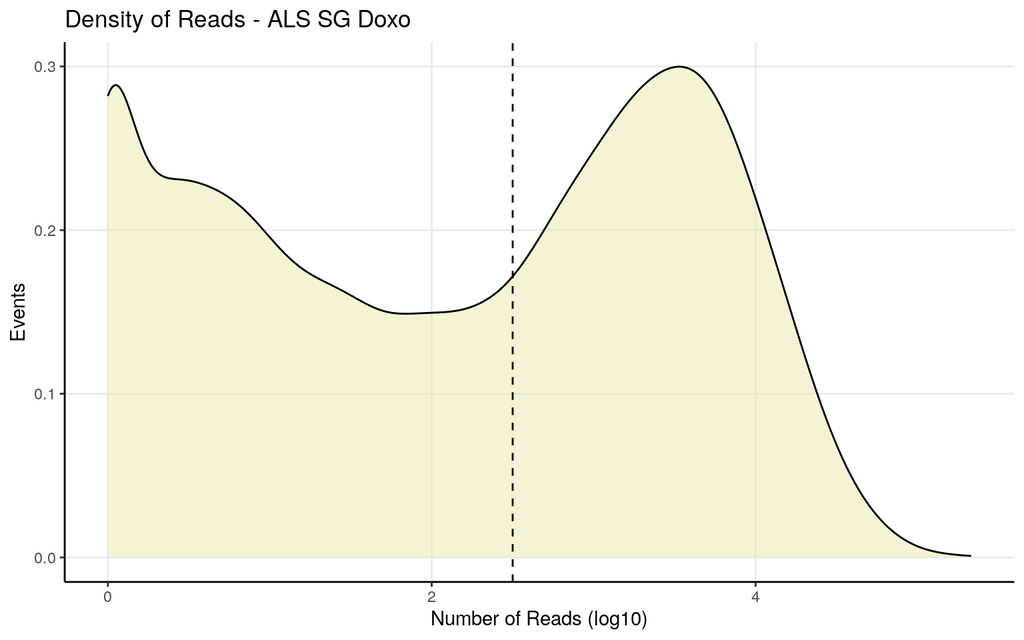

```r
ggplot(alternew.ALSSG_D, aes(x=alternew.ALSSG_D)) + geom_density(fill="#EEE8AA", alpha=0.5) + theme_bw() + geom_vline(xintercept = 2.5, linetype = "dashed") + ylab("Events") + xlab("Number of Reads (log10)") +
  theme(axis.line = element_line(colour = "black"),
        panel.grid.minor = element_blank(),
        panel.border = element_blank(),
        panel.background = element_blank()) + ggtitle("Density of Reads - ALS SG Doxo")
```

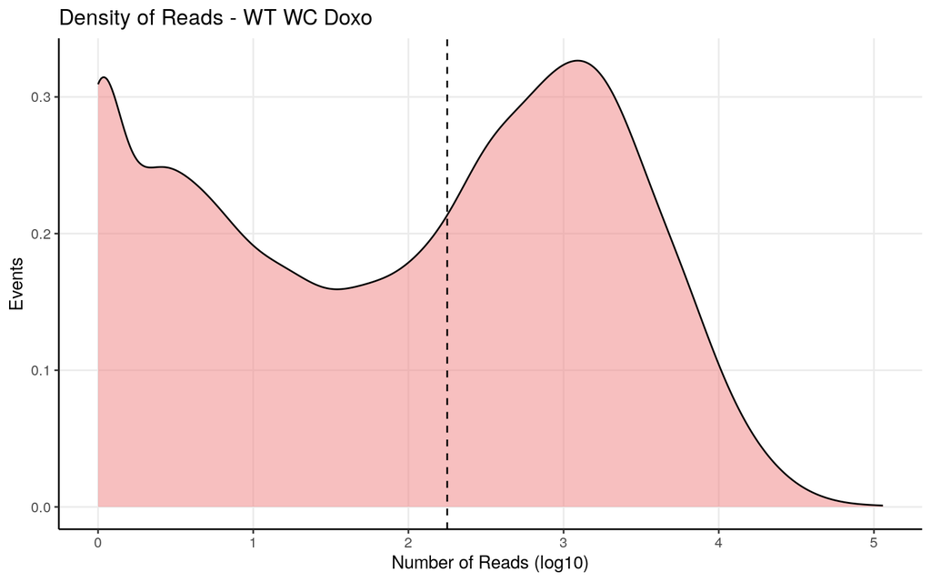

```r
ggplot(alternew.WTWC_D, aes(x=alternew.WTWC_D)) + geom_density(fill="#F08080", alpha=0.5) + theme_bw() + geom_vline(xintercept = 2.25, linetype = "dashed") + ylab("Events") + xlab("Number of Reads (log10)") +
  theme(axis.line = element_line(colour = "black"),
        panel.grid.minor = element_blank(),
        panel.border = element_blank(),
        panel.background = element_blank()) + ggtitle("Density of Reads - WT WC Doxo")
```

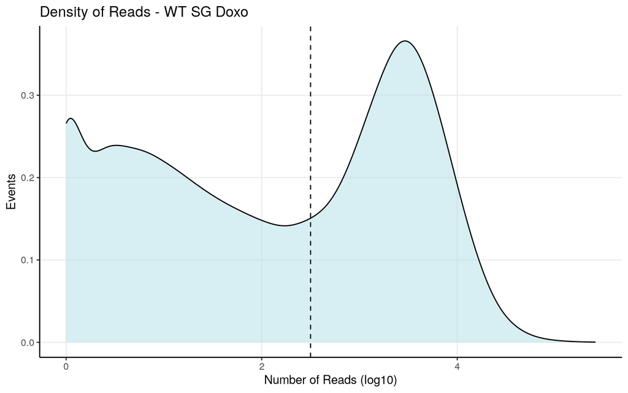

```r
ggplot(alternew.WTSG_D, aes(x=alternew.WTSG_D)) + geom_density(fill="#B0E0E6", alpha=0.5) + theme_bw() + geom_vline(xintercept = 2.5, linetype = "dashed") + ylab("Events") + xlab("Number of Reads (log10)") +
  theme(axis.line = element_line(colour = "black"),
        panel.grid.minor = element_blank(),
        panel.border = element_blank(),
        panel.background = element_blank()) + ggtitle("Density of Reads - WT SG Doxo")
```

By seeing the shape of the graph, we can see where we should cut. We have a **binomial distribution** (low reads and noise vs actual biological meaningful reads). The ideal place to cut them is right before the wedge.

### *After Filtration*

I didn’t do it this time, but I’ve maintained the code to filter by sample type. This time, I considered that it was more correct to filter all samples together.

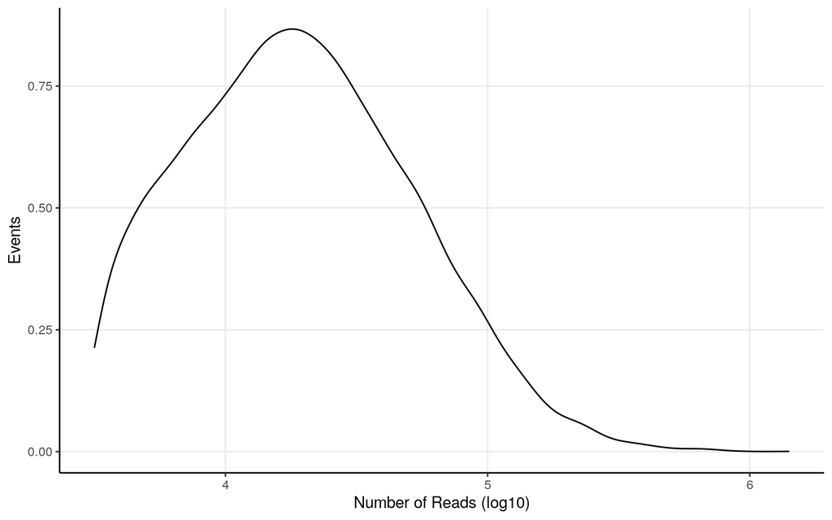

```r
filterednew <- subset(read.counts, alternew>3.5)
filterednew.ALSWC_ND <- subset(read.counts, alternew.ALSWC_ND>2.5)
filterednew.ALSSG_ND <- subset(read.counts, alternew.ALSSG_ND>2.5)
filterednew.WTWC_ND <- subset(read.counts, alternew.WTWC_ND>2.5)
filterednew.WTSG_ND <- subset(read.counts, alternew.WTSG_ND>2.5)
filterednew.ALSWC_D <- subset(read.counts, alternew.ALSWC_D>2.5)
filterednew.ALSSG_D <- subset(read.counts, alternew.ALSSG_D>2.5)
filterednew.WTWC_D <- subset(read.counts, alternew.WTWC_D>2.5)
filterednew.WTSG_D <- subset(read.counts, alternew.WTSG_D>2.5)

#after cutting, its a good idea to visualize again
falternew <- log10(rowSums(filterednew))
falternew <- as.data.frame(falternew)
ggplot(falternew, aes(x=falternew)) + geom_density() + theme_bw() + ylab("Events") + xlab("Number of Reads (log10)") +
  theme(axis.line = element_line(colour = "black"),
        panel.grid.minor = element_blank(),
        panel.border = element_blank(),
        panel.background = element_blank())
```

```r
#lets save the genes which we maintain
impgenes <- c(row.names(falternew))
impgenes.ALSWC_ND <- c(row.names(filterednew.ALSWC_ND))
impgenes.ALSSG_ND <- c(row.names(filterednew.ALSSG_ND))
impgenes.WTWC_ND <- c(row.names(filterednew.WTWC_ND))
impgenes.WTSG_ND <- c(row.names(filterednew.WTSG_ND))
impgenes.ALSWC_D <- c(row.names(filterednew.ALSWC_D))
impgenes.ALSSG_D <- c(row.names(filterednew.ALSSG_D))
impgenes.WTWC_D <- c(row.names(filterednew.WTWC_D))
impgenes.WTSG_D <- c(row.names(filterednew.WTSG_D))

#Now we need to select only the rows which have those genes.
finaltable <- read.counts[row.names(read.counts)%in%impgenes,]
# finaltable <- finaltable[row.names(finaltable)%in%impgenes.ALSWC_ND,]
# finaltable <- finaltable[row.names(finaltable)%in%impgenes.ALSSG_ND,]
# finaltable <- finaltable[row.names(finaltable)%in%impgenes.WTWC_ND,]
# finaltable <- finaltable[row.names(finaltable)%in%impgenes.WTSG_ND,]
# finaltable <- finaltable[row.names(finaltable)%in%impgenes.ALSWC_D,]
# finaltable <- finaltable[row.names(finaltable)%in%impgenes.ALSSG_D,]
# finaltable <- finaltable[row.names(finaltable)%in%impgenes.WTWC_D,]
# finaltable <- finaltable[row.names(finaltable)%in%impgenes.WTSG_D,]
```

## Matrices

Good! Now we can proceed by designing our matrices.

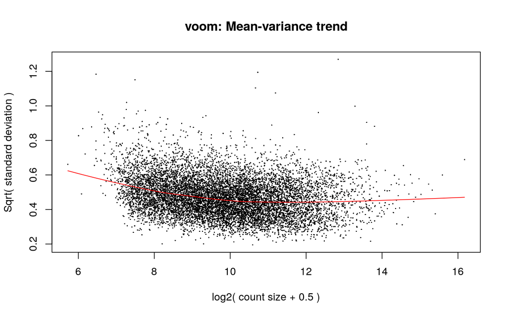

```r
#Let us prepare metadata to add to our samples
#I start by normalizing them all together
#This one has all samples
D0 <- DGEList(finaltable)


#Then we calculate the normalization factors for these new generated data frames
#Bear in mind this step calculates the normalization factors, but does not normalize itself.
D0 <- calcNormFactors(D0)


#Lets create a dataframe with this information
#For potential Batch Effects
CellType <- c("ALS","WT","ALS","WT","WT","ALS","ALS","WT","WT","ALS","ALS","WT","WT","ALS","ALS","WT")
MethilType <- c("CT","CT","KO","KO","CT","KO","CT","KO","CT","KO","CT","KO","CT","KO","CT","KO")
SampleType <- c(rep("WC",3),rep("SG",4),rep("WC",4),rep("SG",4),"WC")



metadata <- data.frame(Cell=CellType, M6A=MethilType, Sample=SampleType)


#Now we do the matrixes
#the one with everything
mm <- model.matrix(~0+SampleColouring)
#the one without pbs


#and now we normalize. This step also turns our counts into log2-counts per million.
#The object with all simple
y <- voom(D0, mm, plot = T)
```

## Normalisation

For normalisation I convert the read counts into log2CPMs. Its a good way to visualise how the reads are.

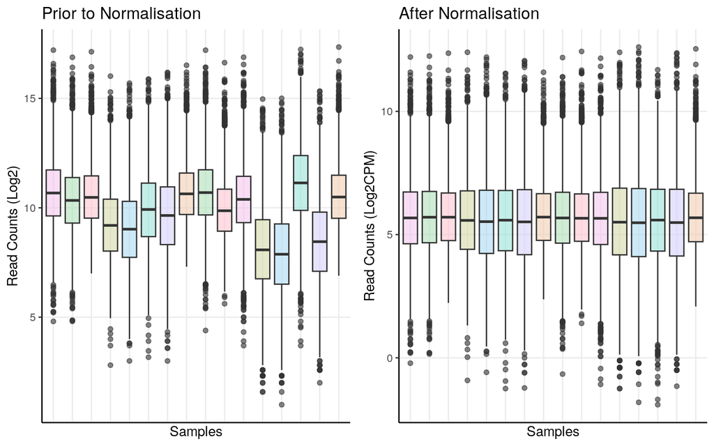

```r
dfforboxy <- finaltable
orderforplots <- SampleColouring
colouring <- data.frame(Sample=colnames(dfforboxy), Types=orderforplots)
dfforboxy <- reshape2::melt(dfforboxy)
colnames(dfforboxy) <- c("Sample", "Expression")
dfforboxy <- merge(dfforboxy, colouring, by="Sample")
# Convert 'Types' to factor with custom order
dfforboxy$Types <- factor(dfforboxy$Types, levels = unique(SampleColouring))

prenorm <- ggplot(dfforboxy, aes(x=Sample, y=(log2(Expression+1)), fill=Types)) + geom_boxplot(alpha=0.6) + theme_bw() + ylab("Read Counts (Log2)") + xlab("Samples") + scale_fill_manual(name = "Sample Type", values = c(custom_palette), labels=c(unique(orderforplots))) +
  theme(axis.line = element_line(colour = "black"),
        panel.grid.minor = element_blank(),
        panel.border = element_blank(),
        panel.background = element_blank(),
        axis.text.x=element_blank(),
        axis.ticks.x=element_blank(),
        legend.position = "None") + ggtitle("Prior to Normalisation")

#Using the Standard Matrix

dfforboxy <- y$E
dfforboxy <- reshape2::melt(dfforboxy)
dfforboxy <- dfforboxy[,-1]
colnames(dfforboxy) <- c("Sample", "Expression")
dfforboxy <- merge(dfforboxy, colouring, by="Sample")
# Convert 'Types' to factor with custom order
dfforboxy$Types <- factor(dfforboxy$Types, levels = unique(SampleColouring))
postnorm <- ggplot(dfforboxy, aes(x=Sample, y=Expression, fill=Types)) + geom_boxplot(alpha=0.6) + theme_bw() + ylab("Read Counts (Log2CPM)") + xlab("Samples") + scale_fill_manual(name = "Sample Type", values = c(custom_palette), labels=c(unique(orderforplots))) +
  theme(axis.line = element_line(colour = "black"),
        panel.grid.minor = element_blank(),
        panel.border = element_blank(),
        panel.background = element_blank(),
        axis.text.x=element_blank(),
        axis.ticks.x=element_blank(),
        legend.position = "None") + ggtitle("After Normalisation")

ggarrange(prenorm, postnorm, nrow=1)
```

## PCA

Before we move on, lets do a **Principal Component analysis**. It is a good exploratory tool to find out how our samples relate to each other and if there are any obvious outliers. We would expect our replicates to be nearer to one another than to other samples, and more different samples should be further away.

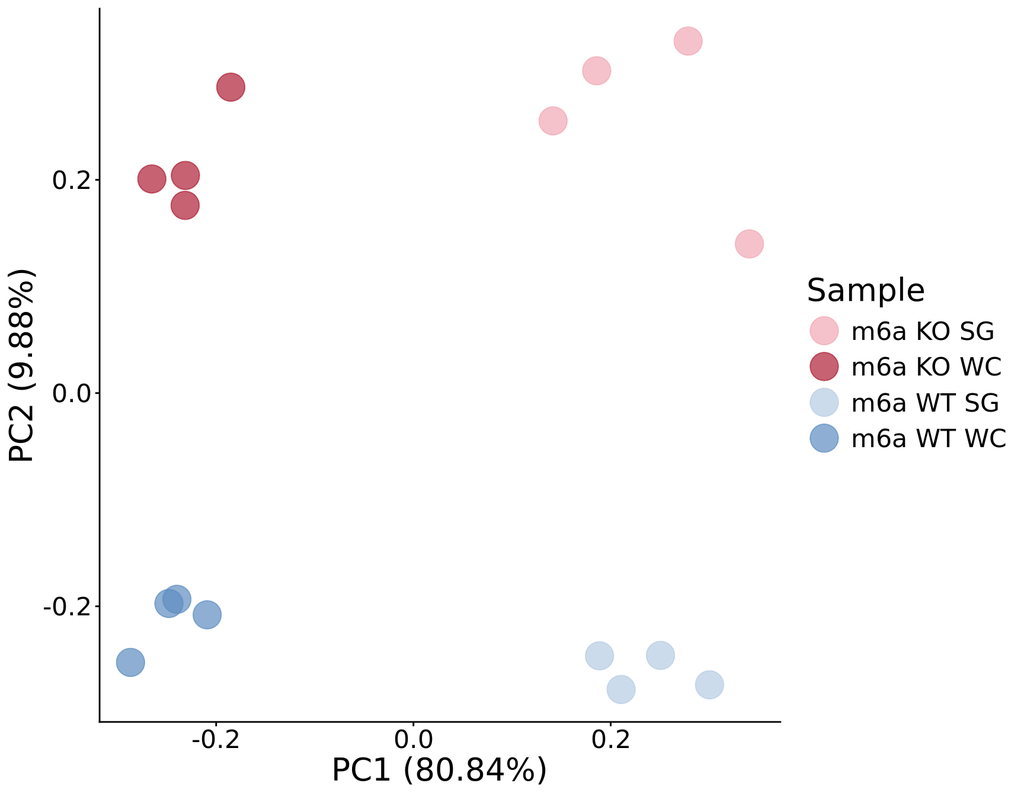

```r
SampleColouring  <- c("m6a WT WC","m6a WT WC","m6a KO WC","m6a KO SG","m6a WT SG","m6a KO SG","m6a WT SG","m6a KO WC","m6a WT WC","m6a KO WC","m6a WT WC","m6a KO SG","m6a WT SG","m6a KO SG","m6a WT SG","m6a KO WC")
# Define color palette
custom_palette <- qualitative_hcl(4, palette = "Pastel")
custom_palette <- sample(custom_palette, 4)
custom_palette <- c("#F0A8B4", "#AD1F36", "#B6CBE2", "#5D8DC0")

#This prepares my data for the PCA
dfforpca <- y$E
dfforpca <- t(dfforpca)
dfforpca <- as.data.frame(dfforpca) # needs to be a data.frame
dfforpca <- apply(dfforpca, 2, as.numeric) # Ensure numeric
dfforpca <- as.data.frame(dfforpca) # still needs to be a data.frame

# Add metadata, which we will then use to plot
dfforpca$Sample <- SampleColouring
dfforpca$M6A <- MethilType
dfforpca$Cell <- CellType

# PCA computation itself. I do one PCA for each variable I want to see.
pca_res <- prcomp(dfforpca[, 1:(ncol(dfforpca)-3)], scale = FALSE)

p_Sample <- autoplot(pca_res, data = dfforpca, x = 1, y = 2, colour = "Sample", size = 8, alpha = 0.7) +
  theme_bw() +
  scale_colour_manual(name = "Sample", values = custom_palette) +
  theme(plot.title = element_text(hjust = 0.5),
        axis.line = element_line(colour = "black"),
        panel.grid.minor = element_blank(),
        panel.border = element_blank(),
        panel.background = element_blank())+ theme_classic() +
  theme(axis.line = element_line(colour = "black")) +
  theme(text=element_text(size=20,  family="Arial MS"))
p_M6A <- autoplot(pca_res, data = dfforpca, x = 1, y = 2, colour = "M6A", size = 8) +
  theme_bw() +
  scale_colour_manual(name = "M6A", values = custom_palette) +
  ggtitle("PCA - Coloured by M6A") +
  theme(plot.title = element_text(hjust = 0.5),
        axis.line = element_line(colour = "black"),
        panel.grid.minor = element_blank(),
        panel.border = element_blank(),
        panel.background = element_blank())

p_Cell <- autoplot(pca_res, data = dfforpca, x = 1, y = 2, colour = "Cell", size = 8) +
  theme_bw() +
  scale_colour_manual(name = "Cell", values = custom_palette) +
  ggtitle("PCA - Coloured by Cell") +
  theme(plot.title = element_text(hjust = 0.5),
        axis.line = element_line(colour = "black"),
        panel.grid.minor = element_blank(),
        panel.border = element_blank(),
        panel.background = element_blank())

p_Sample
```

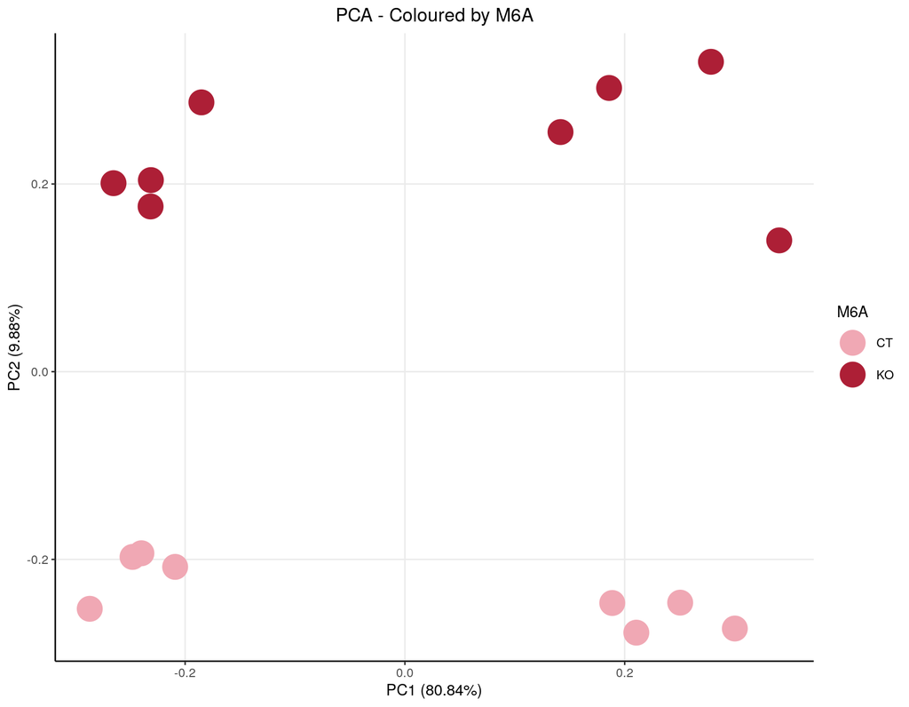

```r
p_M6A
```

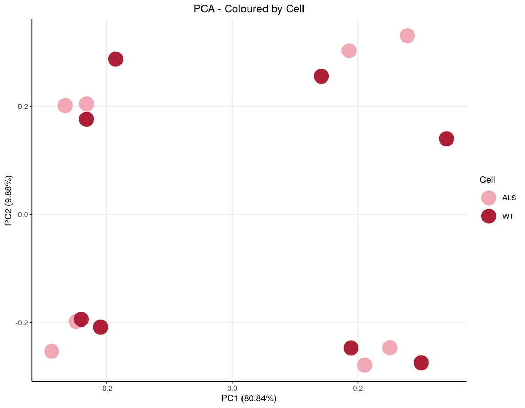

```r
p_Cell
```

```r
png("~/Images/PCA_Example5.png", width = 7, height=4, units = "in", res=300)
p_Sample
dev.off()
```

```r
#in case you want to see most important genes for PCA yourself
contribs1 <- pca_res$rotation[,1]
contribs2 <- pca_res$rotation[,2]

#These are the biggest contributors to the PCA1 (right side)
(pos1genes <- sort(contribs1, decreasing=T)[1:10])
```

```
##       PLEC   MIR600HG      KMT2D        BSN      HERC2     TNRC18     AHNAK2
## 0.02264865 0.02206709 0.02160391 0.02074201 0.02064412 0.02036615 0.02030686
##     BAHCC1      HIPK2      MACF1
## 0.02018857 0.02006561 0.02002052
```

```r
#These are the biggest contributors to the PCA1 (left side)
(neg1genes <- sort(contribs1, decreasing=F)[1:10])
```

```
##      MT-ND3      RNU6-2      H2AC20      RN7SL3       H3C10     RN7SL4P
## -0.04036632 -0.04033860 -0.03953000 -0.03882469 -0.03846333 -0.03843625
##      H2BC11        H3C2        H3C7       H3C13
## -0.03820293 -0.03793864 -0.03768610 -0.03755516
```

```r
#These are the biggest contributors to the PCA2 (up side)
(pos2genes <- sort(contribs2, decreasing=T)[1:10])
```

```
##      FBLN2     NOTCH2    GALNT16     SLC8A2        GSN       BCAM     COL1A1
## 0.09808280 0.09698442 0.09524251 0.08433881 0.08155851 0.08038012 0.07229114
##      KCNN3      ITGA3     ZNF641
## 0.07115646 0.07082428 0.06866220
```

```r
#These are the biggest contributors to the PCA2 (down side)
(neg2genes <- sort(contribs2, decreasing=F)[1:10])
```

```
##        STC2        DKK1        TLE3        RTL1   LINC00639        HES1
## -0.03901465 -0.03592124 -0.03387161 -0.03300634 -0.03232346 -0.03013335
##       APLNR      SEMA5B       CHAC1        TLE1
## -0.02945262 -0.02938586 -0.02926641 -0.02865192
```

As we can observe on the plot, PC1 is driven by sample type, and PC2 is driven by m6A status.

# Simple Linear Models

```r
SampleColouring  <- c("ALWCCT","WTWCCT","ALWCEX","WTSGEX","WTSGCT","ALSGEX","ALSGCT","WTWCEX","WTWCCT","ALWCEX","ALWCCT","WTSGEX","WTSGCT","ALSGEX","ALSGCT","WTWCEX")
mm <- model.matrix(~0+SampleColouring)
fitted <- lmFit(y, mm)
head(coef(fitted))
```

```
##          SampleColouringALSGCT SampleColouringALSGEX SampleColouringALWCCT
## A1BG-AS1              5.138619              5.532360              3.924289
## AAAS                  5.829701              5.560291              6.878930
## AACS                  6.067695              6.112001              5.914414
## AADAT                 3.746200              3.485048              4.549290
## AAGAB                 5.932453              6.006103              6.439615
## AAK1                  7.167454              7.381261              5.783071
##          SampleColouringALWCEX SampleColouringWTSGCT SampleColouringWTSGEX
## A1BG-AS1              4.514969              5.186189              5.786717
## AAAS                  6.912330              6.132604              5.942676
## AACS                  6.179367              6.218344              6.372440
## AADAT                 4.388452              3.756218              3.819003
## AAGAB                 6.145710              5.675714              5.670981
## AAK1                  5.912785              7.109989              7.158979
##          SampleColouringWTWCCT SampleColouringWTWCEX
## A1BG-AS1              4.175228              4.453664
## AAAS                  7.022227              6.691717
## AACS                  6.072165              6.171587
## AADAT                 4.347705              4.354719
## AAGAB                 6.299819              6.295126
## AAK1                  5.989329              6.495179
```

```r
WT.CT <- makeContrasts(SampleColouringWTSGCT   - SampleColouringWTWCCT     , levels = coef(fitted))
WT.EX <- makeContrasts(SampleColouringWTSGEX    - SampleColouringWTWCEX    , levels = coef(fitted))
ALS.CT <- makeContrasts(SampleColouringALSGCT    - SampleColouringALWCCT     , levels = coef(fitted))
ALS.EX <- makeContrasts(SampleColouringALSGEX    - SampleColouringALWCEX     , levels = coef(fitted))

#
tmp.WT.CT <- contrasts.fit(fitted, WT.CT)
tmp.WT.EX <- contrasts.fit(fitted, WT.EX)
tmp.ALS.CT <- contrasts.fit(fitted, ALS.CT)
tmp.ALS.EX <- contrasts.fit(fitted, ALS.EX)
#
# #Correction for multiple testing
tmp.WT.CT <- eBayes(tmp.WT.CT)
tmp.WT.EX <- eBayes(tmp.WT.EX)
tmp.ALS.CT <- eBayes(tmp.ALS.CT)
tmp.ALS.EX <- eBayes(tmp.ALS.EX)
#
top.table.WT.CT <- topTable(tmp.WT.CT, sort.by = "logFC", n=Inf)
top.table.WT.EX <- topTable(tmp.WT.EX, sort.by = "logFC", n=Inf)
top.table.ALS.CT <- topTable(tmp.ALS.CT, sort.by = "logFC", n=Inf)
top.table.ALS.EX <- topTable(tmp.ALS.EX, sort.by = "logFC", n=Inf)

DEGenes.WT.CT <- top.table.WT.CT
DEGenes.WT.EX <- top.table.WT.EX
DEGenes.ALS.CT <- top.table.ALS.CT
DEGenes.ALS.EX <- top.table.ALS.EX



ndegs=20
```

# FUS WT SG vs WC

## Volcano Plot

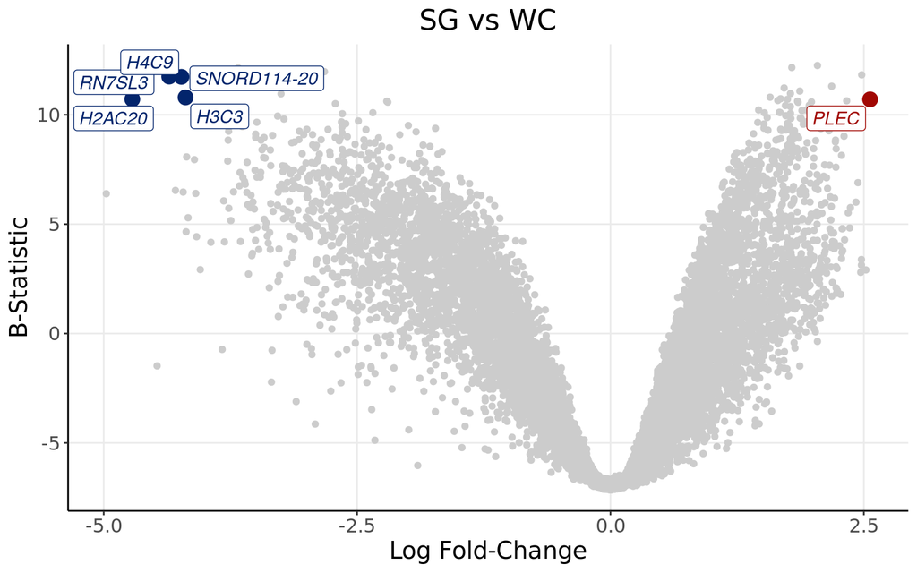

```r
write.table(x = DEGenes.WT.CT,
            file = "~/Projects/StressGranules/SGPAPER/SGvsWC/Timo_WTCT.txt", sep="\t", col.names = TRUE, row.names = TRUE, quote=FALSE)

upmarkers <- as.data.frame(DEGenes.WT.CT[DEGenes.WT.CT$logFC>2.5 & DEGenes.WT.CT$B>10,] )
downmarkers <- as.data.frame(DEGenes.WT.CT[DEGenes.WT.CT$logFC< -4 & DEGenes.WT.CT$B>10,] )

ggplot(data=DEGenes.WT.CT,
                 aes(x=logFC,
                     y=  B)) +
  geom_point(color="#CCCCCC")+
  theme_bw() + ylab("B-Statistic")+xlab("Log Fold-Change")+
  theme(axis.line = element_line(colour = "black"),
        panel.grid.minor = element_blank(),
        panel.border = element_blank(),
        panel.background = element_blank()) +
  ggtitle("SG vs WC")+
  theme(plot.title = element_text(hjust = 0.5), plot.subtitle = element_text(hjust = 0.5)) +
  geom_point(data=upmarkers, aes(x=logFC, y=  B), color="#A10702",size=4)+
  geom_point(data=downmarkers, aes(x=logFC, y=  B), color="#03256C",size=4)+
  geom_label_repel(upmarkers[1:ndegs,] , mapping=aes(label=row.names(upmarkers)[1:ndegs]),size=4,point.padding=-0.5, color="#A10702",max.overlaps = 20, fontface="italic")+
  geom_label_repel(downmarkers[1:ndegs,] , mapping=aes(label=row.names(downmarkers)[1:ndegs]),size=4,point.padding=-0.5, color="#03256C",max.overlaps = 20, fontface="italic")+
  theme(text=element_text(size=15,  family="Arial MS"))
```

## Volcano Plot with Transcript Length

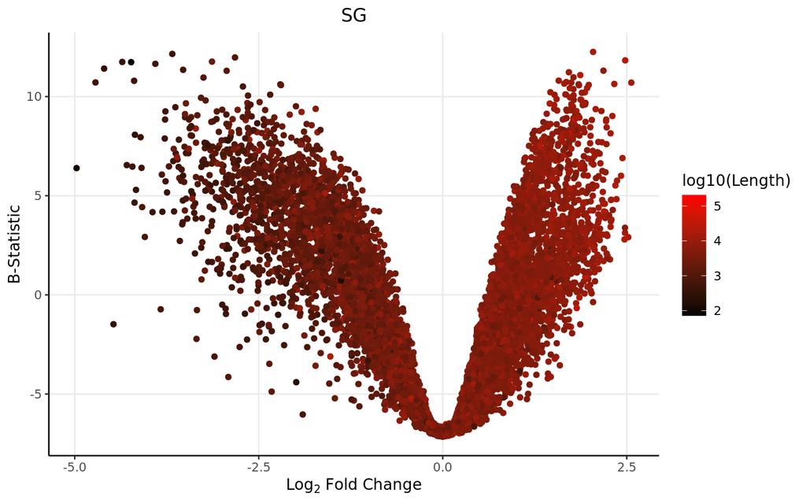

```r
DEGenes.WT.CT$Gene <- row.names(DEGenes.WT.CT)
colnames(genelength) <- c("Length","Gene")
DEGenes.WT.CT <- merge(DEGenes.WT.CT, genelength, by="Gene")

ggplot(data=DEGenes.WT.CT,
                 aes(x=logFC,
                     y=  B)) +
  geom_point(aes(color=log10(Length)))+
  theme_bw() +
  theme(axis.line = element_line(colour = "black"),
        panel.grid.minor = element_blank(),
        panel.border = element_blank(),
        panel.background = element_blank()) +
  ggtitle("SG")+ xlab(expression(Log[2] ~ Fold ~ Change)) + ylab("B-Statistic") +
  theme(plot.title = element_text(hjust = 0.5))  +
  scale_colour_gradient(low = "black", high = "red")+ theme(text=element_text(family = "Quicksand"))
```

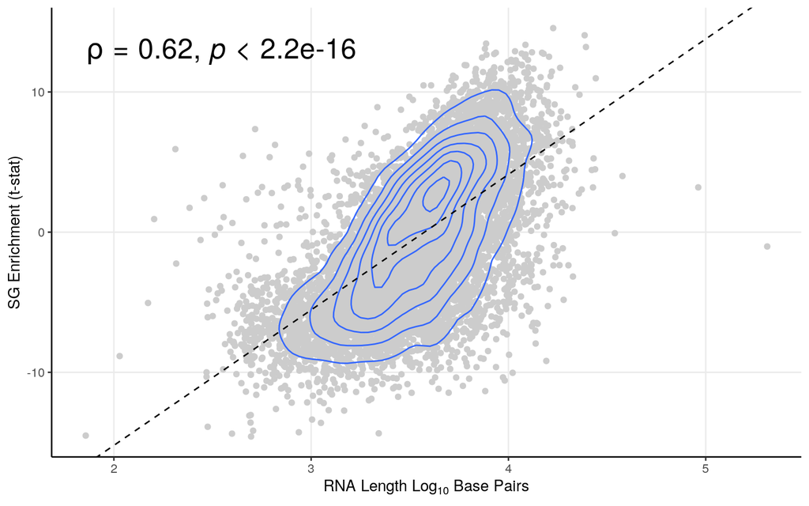

```r
smooth.SG <- lm(t~log10(Length), DEGenes.WT.CT)
liner.SG <- rstandard(smooth.SG)
DEGenes.WT.CT <-cbind(DEGenes.WT.CT, liner.SG)
colnames(DEGenes.WT.CT)[9] <- "Residuals"
row.names(DEGenes.WT.CT) <- DEGenes.WT.CT$Gene
linemarkers <- as.data.frame(DEGenes.WT.CT[abs(DEGenes.WT.CT$Residuals)>4,])

# Calculate the Spearman correlation coefficient
spearman_corr <- cor(DEGenes.WT.CT$t, log10(DEGenes.WT.CT$Length), method = "pearson")



ggplot(DEGenes.WT.CT, aes(y=t, x=log10(Length))) + geom_point(color="#CCCCCC", alpha=1) +   theme_bw()+ geom_density_2d()+
 ylab("SG Enrichment (t-stat)") + xlab(expression(RNA ~ Length ~ Log[10] ~ Base ~ Pairs)) +
  theme(axis.line = element_line(colour = "black"),
        panel.grid.minor = element_blank(),
        panel.border = element_blank(),
        panel.background = element_blank()) +
  theme(plot.title = element_text(hjust = 0.5))  +
  geom_abline(slope=smooth.SG$coefficients[2], intercept = smooth.SG$coefficients[1], linetype = "dashed")+ stat_cor(method = "spearman", cor.coef.name = "rho",size=7)
```

# FUS WT m6A KD SG vs WC

## Volcano Plot

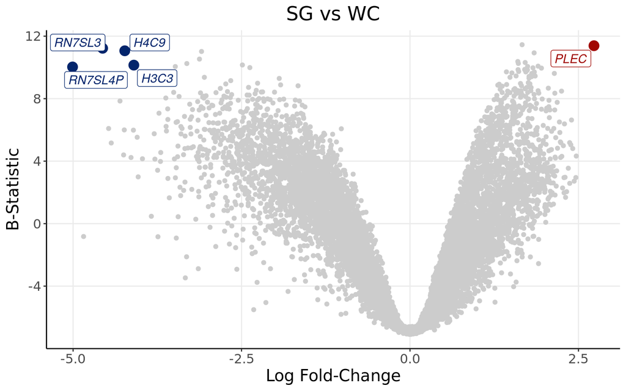

```r
write.table(x = DEGenes.WT.EX,
            file = "~/Projects/StressGranules/SGPAPER/SGvsWC/Timo_WTEX.txt", sep="\t", col.names = TRUE, row.names = TRUE, quote=FALSE)

upmarkers <- as.data.frame(DEGenes.WT.EX[DEGenes.WT.EX$logFC>2.5 & DEGenes.WT.EX$B>10,] )
downmarkers <- as.data.frame(DEGenes.WT.EX[DEGenes.WT.EX$logFC< -4 & DEGenes.WT.EX$B>10,] )

ggplot(data=DEGenes.WT.EX,
                 aes(x=logFC,
                     y=  B)) +
  geom_point(color="#CCCCCC")+
  theme_bw() + ylab("B-Statistic")+xlab("Log Fold-Change")+
  theme(axis.line = element_line(colour = "black"),
        panel.grid.minor = element_blank(),
        panel.border = element_blank(),
        panel.background = element_blank()) +
  ggtitle("SG vs WC")+
  theme(plot.title = element_text(hjust = 0.5), plot.subtitle = element_text(hjust = 0.5)) +
  geom_point(data=upmarkers, aes(x=logFC, y=  B), color="#A10702",size=4)+
  geom_point(data=downmarkers, aes(x=logFC, y=  B), color="#03256C",size=4)+
  geom_label_repel(upmarkers[1:ndegs,] , mapping=aes(label=row.names(upmarkers)[1:ndegs]),size=4,point.padding=-0.5, color="#A10702",max.overlaps = 20, fontface="italic")+
  geom_label_repel(downmarkers[1:ndegs,] , mapping=aes(label=row.names(downmarkers)[1:ndegs]),size=4,point.padding=-0.5, color="#03256C",max.overlaps = 20, fontface="italic")+
  theme(text=element_text(size=15,  family="Arial MS"))
```

## Volcano Plot with Transcript Length

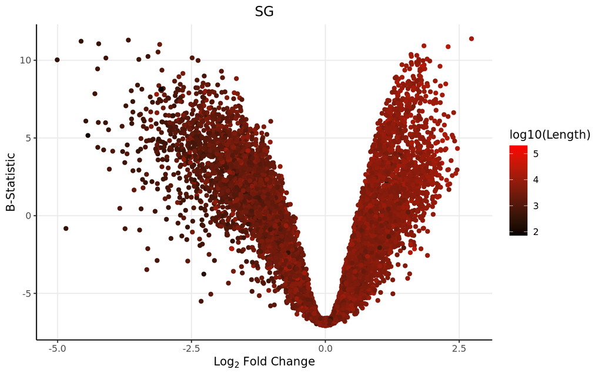

```r
DEGenes.WT.EX$Gene <- row.names(DEGenes.WT.EX)
colnames(genelength) <- c("Length","Gene")
DEGenes.WT.EX <- merge(DEGenes.WT.EX, genelength, by="Gene")

ggplot(data=DEGenes.WT.EX,
                 aes(x=logFC,
                     y=  B)) +
  geom_point(aes(color=log10(Length)))+
  theme_bw() +
  theme(axis.line = element_line(colour = "black"),
        panel.grid.minor = element_blank(),
        panel.border = element_blank(),
        panel.background = element_blank()) +
  ggtitle("SG")+ xlab(expression(Log[2] ~ Fold ~ Change)) + ylab("B-Statistic") +
  theme(plot.title = element_text(hjust = 0.5))  +
  scale_colour_gradient(low = "black", high = "red")+ theme(text=element_text(family = "Quicksand"))
```

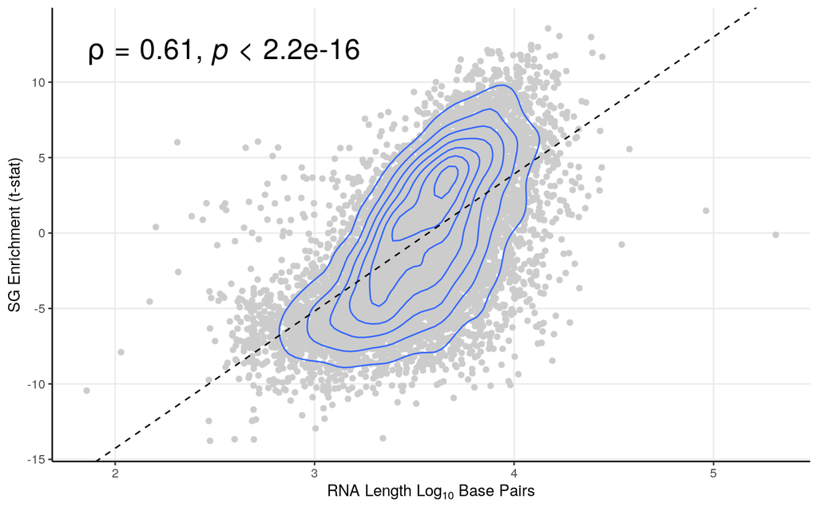

```r
smooth.SG <- lm(t~log10(Length), DEGenes.WT.EX)
liner.SG <- rstandard(smooth.SG)
DEGenes.WT.EX <-cbind(DEGenes.WT.EX, liner.SG)
colnames(DEGenes.WT.EX)[9] <- "Residuals"
row.names(DEGenes.WT.EX) <- DEGenes.WT.EX$Gene
linemarkers <- as.data.frame(DEGenes.WT.EX[abs(DEGenes.WT.EX$Residuals)>4,])

# Calculate the Spearman correlation coefficient
spearman_corr <- cor(DEGenes.WT.EX$t, log10(DEGenes.WT.EX$Length), method = "pearson")



ggplot(DEGenes.WT.EX, aes(y=t, x=log10(Length))) + geom_point(color="#CCCCCC", alpha=1) +   theme_bw()+ geom_density_2d()+
 ylab("SG Enrichment (t-stat)") + xlab(expression(RNA ~ Length ~ Log[10] ~ Base ~ Pairs)) +
  theme(axis.line = element_line(colour = "black"),
        panel.grid.minor = element_blank(),
        panel.border = element_blank(),
        panel.background = element_blank()) +
  theme(plot.title = element_text(hjust = 0.5))  +
  geom_abline(slope=smooth.SG$coefficients[2], intercept = smooth.SG$coefficients[1], linetype = "dashed")+ stat_cor(method = "spearman", cor.coef.name = "rho",size=7)
```

# FUS mut SG vs WC

## Volcano Plot

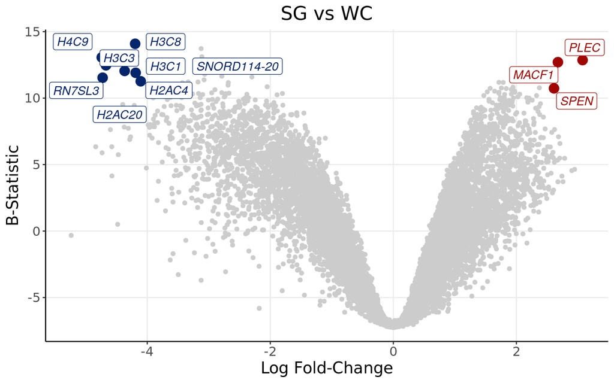

```r
write.table(x = DEGenes.ALS.CT,
            file = "~/Projects/StressGranules/SGPAPER/SGvsWC/Timo_ALSCT.txt", sep="\t", col.names = TRUE, row.names = TRUE, quote=FALSE)

upmarkers <- as.data.frame(DEGenes.ALS.CT[DEGenes.ALS.CT$logFC>2.5 & DEGenes.ALS.CT$B>10,] )
downmarkers <- as.data.frame(DEGenes.ALS.CT[DEGenes.ALS.CT$logFC< -4 & DEGenes.ALS.CT$B>10,] )

ggplot(data=DEGenes.ALS.CT,
                 aes(x=logFC,
                     y=  B)) +
  geom_point(color="#CCCCCC")+
  theme_bw() + ylab("B-Statistic")+xlab("Log Fold-Change")+
  theme(axis.line = element_line(colour = "black"),
        panel.grid.minor = element_blank(),
        panel.border = element_blank(),
        panel.background = element_blank()) +
  ggtitle("SG vs WC")+
  theme(plot.title = element_text(hjust = 0.5), plot.subtitle = element_text(hjust = 0.5)) +
  geom_point(data=upmarkers, aes(x=logFC, y=  B), color="#A10702",size=4)+
  geom_point(data=downmarkers, aes(x=logFC, y=  B), color="#03256C",size=4)+
  geom_label_repel(upmarkers[1:ndegs,] , mapping=aes(label=row.names(upmarkers)[1:ndegs]),size=4,point.padding=-0.5, color="#A10702",max.overlaps = 20, fontface="italic")+
  geom_label_repel(downmarkers[1:ndegs,] , mapping=aes(label=row.names(downmarkers)[1:ndegs]),size=4,point.padding=-0.5, color="#03256C",max.overlaps = 20, fontface="italic")+
  theme(text=element_text(size=15,  family="Arial MS"))
```

## Volcano Plot with Transcript Length

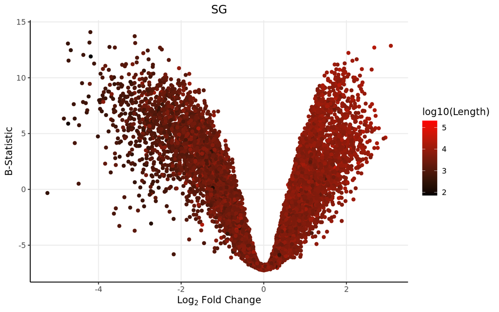

```r
DEGenes.ALS.CT$Gene <- row.names(DEGenes.ALS.CT)
colnames(genelength) <- c("Length","Gene")
DEGenes.ALS.CT <- merge(DEGenes.ALS.CT, genelength, by="Gene")

ggplot(data=DEGenes.ALS.CT,
                 aes(x=logFC,
                     y=  B)) +
  geom_point(aes(color=log10(Length)))+
  theme_bw() +
  theme(axis.line = element_line(colour = "black"),
        panel.grid.minor = element_blank(),
        panel.border = element_blank(),
        panel.background = element_blank()) +
  ggtitle("SG")+ xlab(expression(Log[2] ~ Fold ~ Change)) + ylab("B-Statistic") +
  theme(plot.title = element_text(hjust = 0.5))  +
  scale_colour_gradient(low = "black", high = "red")+ theme(text=element_text(family = "Quicksand"))
```

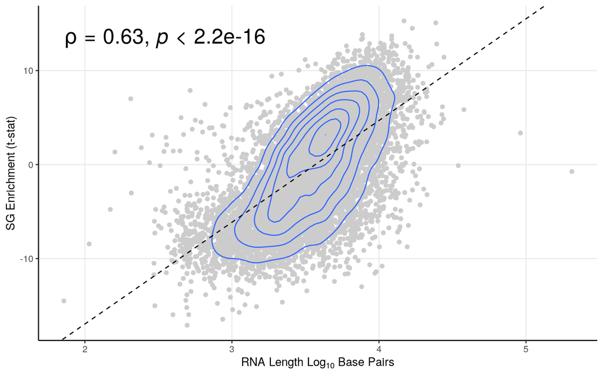

```r
smooth.SG <- lm(t~log10(Length), DEGenes.ALS.CT)
liner.SG <- rstandard(smooth.SG)
DEGenes.ALS.CT <-cbind(DEGenes.ALS.CT, liner.SG)
colnames(DEGenes.ALS.CT)[9] <- "Residuals"
row.names(DEGenes.ALS.CT) <- DEGenes.ALS.CT$Gene
linemarkers <- as.data.frame(DEGenes.ALS.CT[abs(DEGenes.ALS.CT$Residuals)>4,])

# Calculate the Spearman correlation coefficient
spearman_corr <- cor(DEGenes.ALS.CT$t, log10(DEGenes.ALS.CT$Length), method = "pearson")



ggplot(DEGenes.ALS.CT, aes(y=t, x=log10(Length))) + geom_point(color="#CCCCCC", alpha=1) +   theme_bw()+ geom_density_2d()+
 ylab("SG Enrichment (t-stat)") + xlab(expression(RNA ~ Length ~ Log[10] ~ Base ~ Pairs)) +
  theme(axis.line = element_line(colour = "black"),
        panel.grid.minor = element_blank(),
        panel.border = element_blank(),
        panel.background = element_blank()) +
  theme(plot.title = element_text(hjust = 0.5))  +
  geom_abline(slope=smooth.SG$coefficients[2], intercept = smooth.SG$coefficients[1], linetype = "dashed")+ stat_cor(method = "spearman", cor.coef.name = "rho",size=7)
```

# FUS mut m6A KD SG vs WC

## Volcano Plot

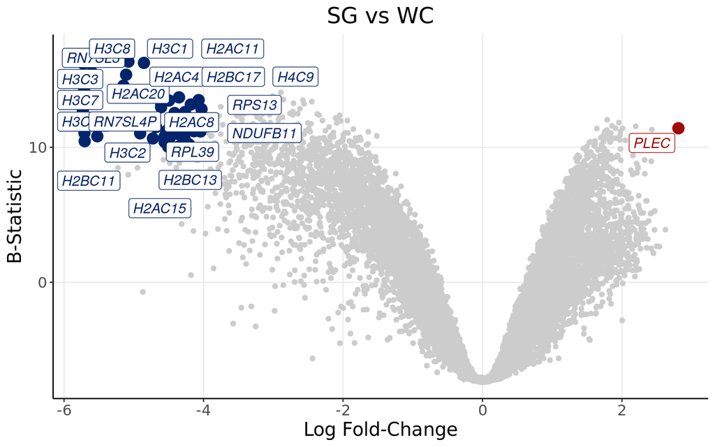

```r
write.table(x = DEGenes.ALS.EX,
            file = "~/Projects/StressGranules/SGPAPER/SGvsWC/Timo_ALSEX.txt", sep="\t", col.names = TRUE, row.names = TRUE, quote=FALSE)

upmarkers <- as.data.frame(DEGenes.ALS.EX[DEGenes.ALS.EX$logFC>2.5 & DEGenes.ALS.EX$B>10,] )
downmarkers <- as.data.frame(DEGenes.ALS.EX[DEGenes.ALS.EX$logFC< -4 & DEGenes.ALS.EX$B>10,] )

ggplot(data=DEGenes.ALS.EX,
                 aes(x=logFC,
                     y=  B)) +
  geom_point(color="#CCCCCC")+
  theme_bw() + ylab("B-Statistic")+xlab("Log Fold-Change")+
  theme(axis.line = element_line(colour = "black"),
        panel.grid.minor = element_blank(),
        panel.border = element_blank(),
        panel.background = element_blank()) +
  ggtitle("SG vs WC")+
  theme(plot.title = element_text(hjust = 0.5), plot.subtitle = element_text(hjust = 0.5)) +
  geom_point(data=upmarkers, aes(x=logFC, y=  B), color="#A10702",size=4)+
  geom_point(data=downmarkers, aes(x=logFC, y=  B), color="#03256C",size=4)+
  geom_label_repel(upmarkers[1:ndegs,] , mapping=aes(label=row.names(upmarkers)[1:ndegs]),size=4,point.padding=-0.5, color="#A10702",max.overlaps = 20, fontface="italic")+
  geom_label_repel(downmarkers[1:ndegs,] , mapping=aes(label=row.names(downmarkers)[1:ndegs]),size=4,point.padding=-0.5, color="#03256C",max.overlaps = 20, fontface="italic")+
  theme(text=element_text(size=15,  family="Arial MS"))
```

## Volcano Plot with Transcript Length

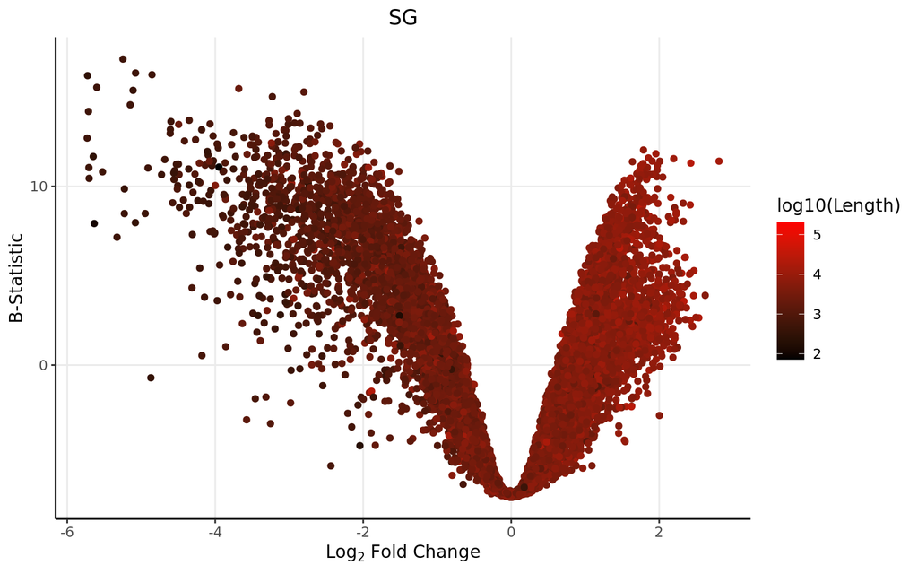

```r
DEGenes.ALS.EX$Gene <- row.names(DEGenes.ALS.EX)
colnames(genelength) <- c("Length","Gene")
DEGenes.ALS.EX <- merge(DEGenes.ALS.EX, genelength, by="Gene")

ggplot(data=DEGenes.ALS.EX,
                 aes(x=logFC,
                     y=  B)) +
  geom_point(aes(color=log10(Length)))+
  theme_bw() +
  theme(axis.line = element_line(colour = "black"),
        panel.grid.minor = element_blank(),
        panel.border = element_blank(),
        panel.background = element_blank()) +
  ggtitle("SG")+ xlab(expression(Log[2] ~ Fold ~ Change)) + ylab("B-Statistic") +
  theme(plot.title = element_text(hjust = 0.5))  +
  scale_colour_gradient(low = "black", high = "red")+ theme(text=element_text(family = "Quicksand"))
```

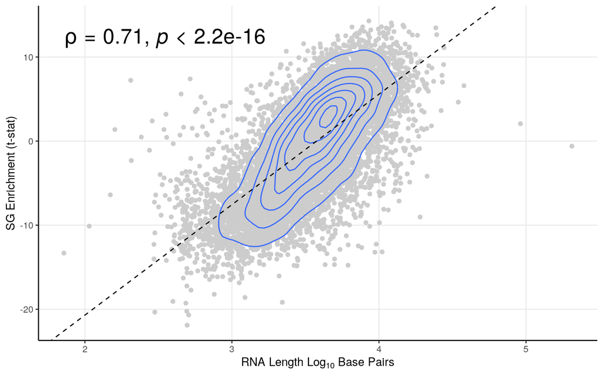

```r
smooth.SG <- lm(t~log10(Length), DEGenes.ALS.EX)
liner.SG <- rstandard(smooth.SG)
DEGenes.ALS.EX <-cbind(DEGenes.ALS.EX, liner.SG)
colnames(DEGenes.ALS.EX)[9] <- "Residuals"
row.names(DEGenes.ALS.EX) <- DEGenes.ALS.EX$Gene
linemarkers <- as.data.frame(DEGenes.ALS.EX[abs(DEGenes.ALS.EX$Residuals)>4,])

# Calculate the Spearman correlation coefficient
spearman_corr <- cor(DEGenes.ALS.EX$t, log10(DEGenes.ALS.EX$Length), method = "pearson")



ggplot(DEGenes.ALS.EX, aes(y=t, x=log10(Length))) + geom_point(color="#CCCCCC", alpha=1) +   theme_bw()+ geom_density_2d()+
 ylab("SG Enrichment (t-stat)") + xlab(expression(RNA ~ Length ~ Log[10] ~ Base ~ Pairs)) +
  theme(axis.line = element_line(colour = "black"),
        panel.grid.minor = element_blank(),
        panel.border = element_blank(),
        panel.background = element_blank()) +
  theme(plot.title = element_text(hjust = 0.5))  +
  geom_abline(slope=smooth.SG$coefficients[2], intercept = smooth.SG$coefficients[1], linetype = "dashed")+ stat_cor(method = "spearman", cor.coef.name = "rho",size=7)
```

# Complex Linear Models

```r
SampleType <- factor(SampleType)
SampleType <- relevel(SampleType,"WC")

CellType <- factor(CellType)
CellType <- relevel(CellType,"WT")

MethilType <- factor(MethilType)
MethilType <- relevel(MethilType,"KO")


mm <- model.matrix(~0+Sample+Cell+M6A, metadata)
fitted <- lmFit(y, mm)
head(coef(fitted))
```

```
##          SampleSG SampleWC       CellWT       M6AKO
## A1BG-AS1 5.118484 3.973754  0.126267091  0.45758072
## AAAS     5.884985 6.904168  0.134193957 -0.19026295
## AACS     6.049352 5.944872  0.137606786  0.14089275
## AADAT    3.732354 4.464953 -0.005960829 -0.10226328
## AAGAB    5.932558 6.392459 -0.130901156 -0.06211729
## AAK1     7.027312 5.866927  0.131520137  0.22928111
```

```r
contrastas <- makeContrasts(SampleSG   - SampleWC    , levels = coef(fitted))
#
tmp <- contrasts.fit(fitted, contrastas)
#
# #Correction for multiple testing
tmp <- eBayes(tmp)
#
top.table <- topTable(tmp, sort.by = "logFC", n=Inf)

DEGenes <- top.table



ndegs=20
```

# SG vs Non-SG

## Volcano Plot

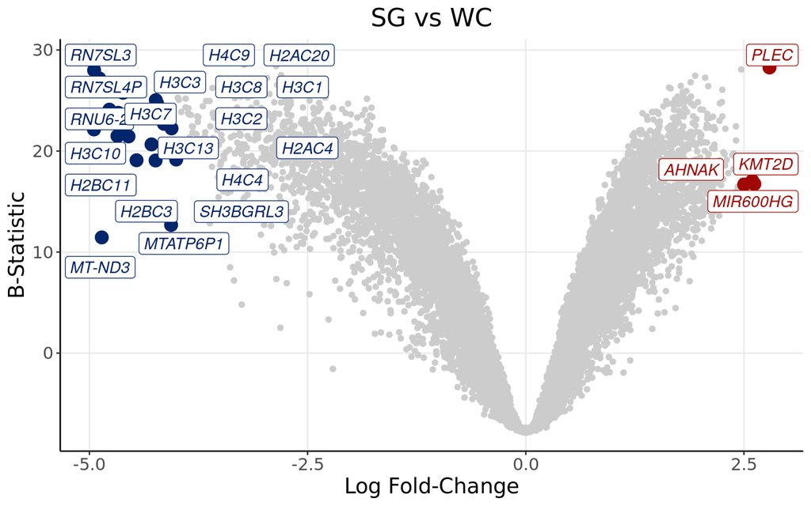

```r
write.table(x = DEGenes,
            file = "~/Projects/StressGranules/SGPAPER/SGvsWC/SGm6A.txt", sep="\t", col.names = TRUE, row.names = TRUE, quote=FALSE)

upmarkers <- as.data.frame(DEGenes[DEGenes$logFC>2.5 & DEGenes$B>10,] )
downmarkers <- as.data.frame(DEGenes[DEGenes$logFC< -4 & DEGenes$B>10,] )

ggplot(data=DEGenes,
                 aes(x=logFC,
                     y=  B)) +
  geom_point(color="#CCCCCC")+
  theme_bw() + ylab("B-Statistic")+xlab("Log Fold-Change")+
  theme(axis.line = element_line(colour = "black"),
        panel.grid.minor = element_blank(),
        panel.border = element_blank(),
        panel.background = element_blank()) +
  ggtitle("SG vs WC")+
  theme(plot.title = element_text(hjust = 0.5), plot.subtitle = element_text(hjust = 0.5)) +
  geom_point(data=upmarkers, aes(x=logFC, y=  B), color="#A10702",size=4)+
  geom_point(data=downmarkers, aes(x=logFC, y=  B), color="#03256C",size=4)+
  geom_label_repel(upmarkers[1:ndegs,] , mapping=aes(label=row.names(upmarkers)[1:ndegs]),size=4,point.padding=-0.5, color="#A10702",max.overlaps = 20, fontface="italic")+
  geom_label_repel(downmarkers[1:ndegs,] , mapping=aes(label=row.names(downmarkers)[1:ndegs]),size=4,point.padding=-0.5, color="#03256C",max.overlaps = 20, fontface="italic")+
  theme(text=element_text(size=15,  family="Arial MS"))
```

## Volcano Plot with Transcript Length

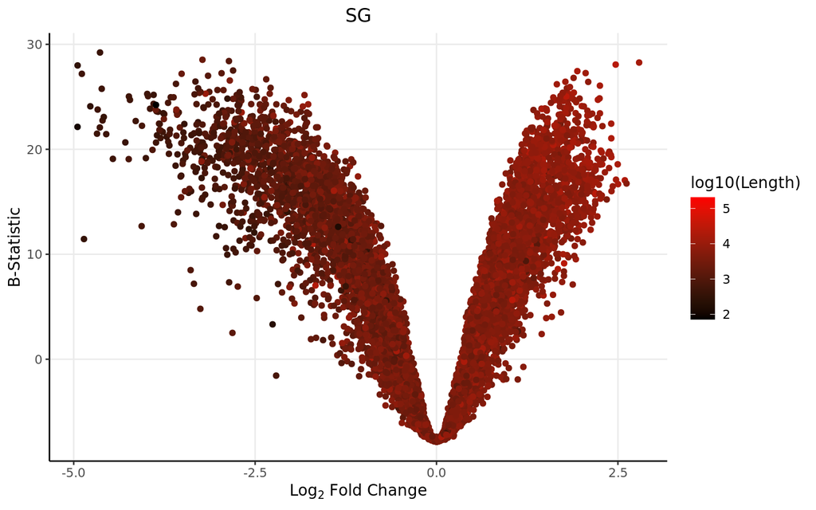

```r
DEGenes$Gene <- row.names(DEGenes)
colnames(genelength) <- c("Length","Gene")
DEGenes <- merge(DEGenes, genelength, by="Gene")

ggplot(data=DEGenes,
                 aes(x=logFC,
                     y=  B)) +
  geom_point(aes(color=log10(Length)))+
  theme_bw() +
  theme(axis.line = element_line(colour = "black"),
        panel.grid.minor = element_blank(),
        panel.border = element_blank(),
        panel.background = element_blank()) +
  ggtitle("SG")+ xlab(expression(Log[2] ~ Fold ~ Change)) + ylab("B-Statistic") +
  theme(plot.title = element_text(hjust = 0.5))  +
  scale_colour_gradient(low = "black", high = "red")+ theme(text=element_text(family = "Quicksand"))
```

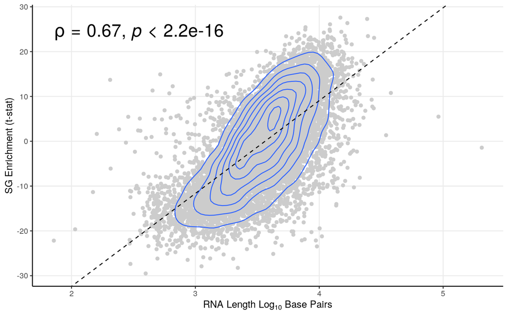

```r
smooth.SG <- lm(t~log10(Length), DEGenes)
liner.SG <- rstandard(smooth.SG)
DEGenes <-cbind(DEGenes, liner.SG)
colnames(DEGenes)[9] <- "Residuals"
row.names(DEGenes) <- DEGenes$Gene
linemarkers <- as.data.frame(DEGenes[abs(DEGenes$Residuals)>4,])

# Calculate the Spearman correlation coefficient
spearman_corr <- cor(DEGenes$t, log10(DEGenes$Length), method = "pearson")



ggplot(DEGenes, aes(y=t, x=log10(Length))) + geom_point(color="#CCCCCC", alpha=1) +   theme_bw()+ geom_density_2d()+
 ylab("SG Enrichment (t-stat)") + xlab(expression(RNA ~ Length ~ Log[10] ~ Base ~ Pairs)) +
  theme(axis.line = element_line(colour = "black"),
        panel.grid.minor = element_blank(),
        panel.border = element_blank(),
        panel.background = element_blank()) +
  theme(plot.title = element_text(hjust = 0.5))  +
  geom_abline(slope=smooth.SG$coefficients[2], intercept = smooth.SG$coefficients[1], linetype = "dashed")+ stat_cor(method = "spearman", cor.coef.name = "rho",size=7)
```